# skimage.transform

Geometric and other transformations, e.g., rotations, Radon transform.

- Geometric transformation: These transforms change the shape or position of an image. They are useful for tasks such as image registration, alignment, and geometric correction. Examples: `AffineTransform`, `ProjectiveTransform`, `EuclideanTransform`.
- Image resizing and rescaling: These transforms change the size or resolution of an image. They are useful for tasks such as down-sampling an image to reduce its size or up-sampling an image to increase its resolution. Examples: `resize()`, `rescale()`.
- Feature detection and extraction: These transforms identify and extract specific features or patterns in an image. They are useful for tasks such as object detection, image segmentation, and feature matching. Examples: `hough_circle()`, `pyramid_expand()`, `radon()`.
- Image transformation: These transforms change the appearance of an image without changing its content. They are useful for tasks such a creating image mosaics, applying artistic effects, and visualizing image data. Examples: `warp()`, `iradon()`.

| `downscale_local_mean` | Down-sample N-dimensional image by local averaging. |
| --- | --- |
| `estimate_transform` | Estimate 2D geometric transformation parameters. |
| `frt2` | Compute the 2-dimensional finite Radon transform (FRT) for the input array. |
| `hough_circle` | Perform a circular Hough transform. |
| `hough_circle_peaks` | Return peaks in a circle Hough transform. |
| `hough_ellipse` | Perform an elliptical Hough transform. |
| `hough_line` | Perform a straight line Hough transform. |
| `hough_line_peaks` | Return peaks in a straight line Hough transform. |
| `ifrt2` | Compute the 2-dimensional inverse finite Radon transform (iFRT) for the input array. |
| `integral_image` | Integral image / summed area table. |
| `integrate` | Use an integral image to integrate over a given window. |
| `iradon` | Inverse radon transform. |
| `iradon_sart` | Inverse radon transform. |
| `matrix_transform` | Apply 2D matrix transform. |
| `order_angles_golden_ratio` | Order angles to reduce the amount of correlated information in subsequent projections. |
| `probabilistic_hough_line` | Return lines from a progressive probabilistic line Hough transform. |
| `pyramid_expand` | Upsample and then smooth image. |
| `pyramid_gaussian` | Yield images of the Gaussian pyramid formed by the input image. |
| `pyramid_laplacian` | Yield images of the laplacian pyramid formed by the input image. |
| `pyramid_reduce` | Smooth and then downsample image. |
| `radon` | Calculates the radon transform of an image given specified projection angles. |
| `rescale` | Scale image by a certain factor. |
| `resize` | Resize image to match a certain size. |
| `resize_local_mean` | Resize an array with the local mean / bilinear scaling. |
| `rotate` | Rotate image by a certain angle around its center. |
| `swirl` | Perform a swirl transformation. |
| `warp` | Warp an image according to a given coordinate transformation. |
| `warp_coords` | Build the source coordinates for the output of a 2-D image warp. |
| `warp_polar` | Remap image to polar or log-polar coordinates space. |
| `AffineTransform` | Affine transformation. |
| `EssentialMatrixTransform` | Essential matrix transformation. |
| `EuclideanTransform` | Euclidean transformation, also known as a rigid transform. |
| `FundamentalMatrixTransform` | Fundamental matrix transformation. |
| `PiecewiseAffineTransform` | Piecewise affine transformation. |
| `PolynomialTransform` | 2D polynomial transformation. |
| `ProjectiveTransform` | Projective transformation. |
| `SimilarityTransform` | Similarity transformation. |
| `ThinPlateSplineTransform` | Thin-plate spline transformation. |

**`skimage.transform.downscale_local_mean(image, factors, cval=0, clip=True)` [[source]](https://github.com/scikit-image/scikit-image/blob/v0.25.0/skimage/transform/_warps.py#L456-L500)**

Down-sample N-dimensional image by local averaging.

The image is padded with `cval` if it is not perfectly divisible by the integer factors.

In contrast to interpolation in `skimage.transform.resize` and `skimage.transform.rescale` this function calculates the local mean of elements in each block of size `factors` in the input image.

**Parameters:**

**`image(M[, …]) ndarray`**

Input image.

**`factorsarray_like`**

Array containing down-sampling integer factor along each axis.

**`cvalfloat, optional`**

Constant padding value if image is not perfectly divisible by the integer factors.

**`clipbool, optional`**

Unused, but kept here for API consistency with the other transforms in this module. (The local mean will never fall outside the range of values in the input image, assuming the provided `cval` also falls within that range.)

**Returns:**

**`imagendarray`**

Down-sampled image with same number of dimensions as input image. For integer inputs, the output dtype will be `float64`. See [`numpy.mean()`](https://numpy.org/doc/stable/reference/generated/numpy.mean.html#numpy.mean) for details.

#### Examples

```
>>> a = np.arange(15).reshape(3, 5)
>>> a
array([[ 0,  1,  2,  3,  4],
       [ 5,  6,  7,  8,  9],
       [10, 11, 12, 13, 14]])
>>> downscale_local_mean(a, (2, 3))
array([[3.5, 4. ],
       [5.5, 4.5]])
```

[Rescale, resize, and downscale](https://scikit-image.org/docs/0.25.x/auto_examples/transform/plot_rescale.html#sphx-glr-auto-examples-transform-plot-rescale-py)

Rescale, resize, and downscale

**`skimage.transform.estimate_transform(ttype, src, dst, *args, **kwargs)` [[source]](https://github.com/scikit-image/scikit-image/blob/v0.25.0/skimage/transform/_geometric.py#L1684-L1753)**

Estimate 2D geometric transformation parameters.

You can determine the over-, well- and under-determined parameters with the total least-squares method.

Number of source and destination coordinates must match.

**Parameters:**

**`ttype{‘euclidean’, similarity’, ‘affine’, ‘piecewise-affine’, ‘projective’, ‘polynomial’}`**

Type of transform.

**`kwargsarray_like or int`**

Function parameters (src, dst, n, angle):

```
NAME / TTYPE        FUNCTION PARAMETERS
'euclidean'         `src, `dst`
'similarity'        `src, `dst`
'affine'            `src, `dst`
'piecewise-affine'  `src, `dst`
'projective'        `src, `dst`
'polynomial'        `src, `dst`, `order` (polynomial order,
                                          default order is 2)
```

Also see examples below.

**Returns:**

**`tform_GeometricTransform`**

Transform object containing the transformation parameters and providing access to forward and inverse transformation functions.

#### Examples

```
>>> import numpy as np
>>> import skimage as ski
```

```
>>> # estimate transformation parameters
>>> src = np.array([0, 0, 10, 10]).reshape((2, 2))
>>> dst = np.array([12, 14, 1, -20]).reshape((2, 2))
```

```
>>> tform = ski.transform.estimate_transform('similarity', src, dst)
```

```
>>> np.allclose(tform.inverse(tform(src)), src)
True
```

```
>>> # warp image using the estimated transformation
>>> image = ski.data.camera()
```

```
>>> ski.transform.warp(image, inverse_map=tform.inverse)
```

```
>>> # create transformation with explicit parameters
>>> tform2 = ski.transform.SimilarityTransform(scale=1.1, rotation=1,
...     translation=(10, 20))
```

```
>>> # unite transformations, applied in order from left to right
>>> tform3 = tform + tform2
>>> np.allclose(tform3(src), tform2(tform(src)))
True
```

**`skimage.transform.frt2(a)` [[source]](https://github.com/scikit-image/scikit-image/blob/v0.25.0/skimage/transform/finite_radon_transform.py#L12-L67)**

Compute the 2-dimensional finite Radon transform (FRT) for the input array.

**Parameters:**

**`andarray of int, shape (M, M)`**

Input array.

**Returns:**

**`FRTndarray of int, shape (M+1, M)`**

Finite Radon Transform array of coefficients.

See also

**`ifrt2`**

The two-dimensional inverse FRT.

#### Notes

The FRT has a unique inverse if and only if M is prime. [FRT] The idea for this algorithm is due to Vlad Negnevitski.

#### References

[FRT]

A. Kingston and I. Svalbe, “Projective transforms on periodic discrete image arrays,” in P. Hawkes (Ed), Advances in Imaging and Electron Physics, 139 (2006)

#### Examples

Generate a test image: Use a prime number for the array dimensions

```
>>> SIZE = 59
>>> img = np.tri(SIZE, dtype=np.int32)
```

Apply the Finite Radon Transform:

```
>>> f = frt2(img)
```

**`skimage.transform.hough_circle(image, radius, normalize=True, full_output=False)` [[source]](https://github.com/scikit-image/scikit-image/blob/v0.25.0/skimage/transform/hough_transform.py#L81-L123)**

Perform a circular Hough transform.

**Parameters:**

**`imagendarray, shape (M, N)`**

Input image with nonzero values representing edges.

**`radiusscalar or sequence of scalars`**

Radii at which to compute the Hough transform. Floats are converted to integers.

**`normalizeboolean, optional`**

Normalize the accumulator with the number of pixels used to draw the radius.

**`full_outputboolean, optional`**

Extend the output size by twice the largest radius in order to detect centers outside the input picture.

**Returns:**

**`Hndarray, shape (radius index, M + 2R, N + 2R)`**

Hough transform accumulator for each radius. R designates the larger radius if full_output is True. Otherwise, R = 0.

#### Examples

```
>>> from skimage.transform import hough_circle
>>> from skimage.draw import circle_perimeter
>>> img = np.zeros((100, 100), dtype=bool)
>>> rr, cc = circle_perimeter(25, 35, 23)
>>> img[rr, cc] = 1
>>> try_radii = np.arange(5, 50)
>>> res = hough_circle(img, try_radii)
>>> ridx, r, c = np.unravel_index(np.argmax(res), res.shape)
>>> r, c, try_radii[ridx]
(25, 35, 23)
```

[Circular and Elliptical Hough Transforms](https://scikit-image.org/docs/0.25.x/auto_examples/edges/plot_circular_elliptical_hough_transform.html#sphx-glr-auto-examples-edges-plot-circular-elliptical-hough-transform-py)

Circular and Elliptical Hough Transforms

**`skimage.transform.hough_circle_peaks(hspaces, radii, min_xdistance=1, min_ydistance=1, threshold=None, num_peaks=inf, total_num_peaks=inf, normalize=False)` [[source]](https://github.com/scikit-image/scikit-image/blob/v0.25.0/skimage/transform/hough_transform.py#L305-L423)**

Return peaks in a circle Hough transform.

Identifies most prominent circles separated by certain distances in given Hough spaces. Non-maximum suppression with different sizes is applied separately in the first and second dimension of the Hough space to identify peaks. For circles with different radius but close in distance, only the one with highest peak is kept.

**Parameters:**

**`hspaces(M, N, P) array`**

Hough spaces returned by the `hough_circle` function.

**`radii(M,) array`**

Radii corresponding to Hough spaces.

**`min_xdistanceint, optional`**

Minimum distance separating centers in the x dimension.

**`min_ydistanceint, optional`**

Minimum distance separating centers in the y dimension.

**`thresholdfloat, optional`**

Minimum intensity of peaks in each Hough space. Default is `0.5 * max(hspace)`.

**`num_peaksint, optional`**

Maximum number of peaks in each Hough space. When the number of peaks exceeds `num_peaks`, only `num_peaks` coordinates based on peak intensity are considered for the corresponding radius.

**`total_num_peaksint, optional`**

Maximum number of peaks. When the number of peaks exceeds `num_peaks`, return `num_peaks` coordinates based on peak intensity.

**`normalizebool, optional`**

If True, normalize the accumulator by the radius to sort the prominent peaks.

**Returns:**

**`accum, cx, cy, radtuple of array`**

Peak values in Hough space, x and y center coordinates and radii.

#### Notes

Circles with bigger radius have higher peaks in Hough space. If larger circles are preferred over smaller ones, `normalize` should be False. Otherwise, circles will be returned in the order of decreasing voting number.

#### Examples

```
>>> from skimage import transform, draw
>>> img = np.zeros((120, 100), dtype=int)
>>> radius, x_0, y_0 = (20, 99, 50)
>>> y, x = draw.circle_perimeter(y_0, x_0, radius)
>>> img[x, y] = 1
>>> hspaces = transform.hough_circle(img, radius)
>>> accum, cx, cy, rad = hough_circle_peaks(hspaces, [radius,])
```

[Circular and Elliptical Hough Transforms](https://scikit-image.org/docs/0.25.x/auto_examples/edges/plot_circular_elliptical_hough_transform.html#sphx-glr-auto-examples-edges-plot-circular-elliptical-hough-transform-py)

Circular and Elliptical Hough Transforms

**`skimage.transform.hough_ellipse(image, threshold=4, accuracy=1, min_size=4, max_size=None)` [[source]](https://github.com/scikit-image/scikit-image/blob/v0.25.0/skimage/transform/hough_transform.py#L126-L190)**

Perform an elliptical Hough transform.

**Parameters:**

**`image(M, N) ndarray`**

Input image with nonzero values representing edges.

**`thresholdint, optional`**

Accumulator threshold value. A lower value will return more ellipses.

**`accuracydouble, optional`**

Bin size on the minor axis used in the accumulator. A higher value will return more ellipses, but lead to a less precise estimation of the minor axis lengths.

**`min_sizeint, optional`**

Minimal major axis length.

**`max_sizeint, optional`**

**Returns:**

**`resultndarray with fields [(accumulator, yc, xc, a, b, orientation)].`**

Where `(yc, xc)` is the center, `(a, b)` the major and minor axes, respectively. The `orientation` value follows the `skimage.draw.ellipse_perimeter` convention.

#### Notes

Potential ellipses in the image are characterized by their major and minor axis lengths. For any pair of nonzero pixels in the image that are at least half of `min_size` apart, an accumulator keeps track of the minor axis lengths of potential ellipses formed with all the other nonzero pixels. If any bin (with `bin_size = accuracy * accuracy`) in the histogram of those accumulated minor axis lengths is above `threshold`, the corresponding ellipse is added to the results.

A higher `accuracy` will therefore lead to more ellipses being found in the image, at the cost of a less precise estimation of the minor axis length.

#### References

[1]

Xie, Yonghong, and Qiang Ji. “A new efficient ellipse detection method.” Pattern Recognition, 2002. Proceedings. 16th International Conference on. Vol. 2. IEEE, 2002

#### Examples

```
>>> from skimage.transform import hough_ellipse
>>> from skimage.draw import ellipse_perimeter
>>> img = np.zeros((25, 25), dtype=np.uint8)
>>> rr, cc = ellipse_perimeter(10, 10, 6, 8)
>>> img[cc, rr] = 1
>>> result = hough_ellipse(img, threshold=8)
>>> result.tolist()
[(10, 10.0, 10.0, 8.0, 6.0, 0.0)]
```

[Circular and Elliptical Hough Transforms](https://scikit-image.org/docs/0.25.x/auto_examples/edges/plot_circular_elliptical_hough_transform.html#sphx-glr-auto-examples-edges-plot-circular-elliptical-hough-transform-py)

Circular and Elliptical Hough Transforms

**`skimage.transform.hough_line(image, theta=None)` [[source]](https://github.com/scikit-image/scikit-image/blob/v0.25.0/skimage/transform/hough_transform.py#L193-L247)**

Perform a straight line Hough transform.

**Parameters:**

**`image(M, N) ndarray`**

Input image with nonzero values representing edges.

**`thetandarray of double, shape (K,), optional`**

Angles at which to compute the transform, in radians. Defaults to a vector of 180 angles evenly spaced in the range [-pi/2, pi/2).

**Returns:**

**`hspacendarray of uint64, shape (P, Q)`**

Hough transform accumulator.

**`anglesndarray`**

Angles at which the transform is computed, in radians.

**`distancesndarray`**

Distance values.

#### Notes

The origin is the top left corner of the original image. X and Y axis are horizontal and vertical edges respectively. The distance is the minimal algebraic distance from the origin to the detected line. The angle accuracy can be improved by decreasing the step size in the `theta` array.

#### Examples

Generate a test image:

```
>>> img = np.zeros((100, 150), dtype=bool)
>>> img[30, :] = 1
>>> img[:, 65] = 1
>>> img[35:45, 35:50] = 1
>>> for i in range(90):
...     img[i, i] = 1
>>> rng = np.random.default_rng()
>>> img += rng.random(img.shape) > 0.95
```

Apply the Hough transform:

```
>>> out, angles, d = hough_line(img)
```

[Straight line Hough transform](https://scikit-image.org/docs/0.25.x/auto_examples/edges/plot_line_hough_transform.html#sphx-glr-auto-examples-edges-plot-line-hough-transform-py)

Straight line Hough transform

**`skimage.transform.hough_line_peaks(hspace, angles, dists, min_distance=9, min_angle=10, threshold=None, num_peaks=inf)` [[source]](https://github.com/scikit-image/scikit-image/blob/v0.25.0/skimage/transform/hough_transform.py#L8-L78)**

Return peaks in a straight line Hough transform.

Identifies most prominent lines separated by a certain angle and distance in a Hough transform. Non-maximum suppression with different sizes is applied separately in the first (distances) and second (angles) dimension of the Hough space to identify peaks.

**Parameters:**

**`hspacendarray, shape (M, N)`**

Hough space returned by the `hough_line` function.

**`anglesarray, shape (N,)`**

Angles returned by the `hough_line` function. Assumed to be continuous. (`angles[-1] - angles[0] == PI`).

**`distsarray, shape (M,)`**

Distances returned by the `hough_line` function.

**`min_distanceint, optional`**

Minimum distance separating lines (maximum filter size for first dimension of hough space).

**`min_angleint, optional`**

Minimum angle separating lines (maximum filter size for second dimension of hough space).

**`thresholdfloat, optional`**

Minimum intensity of peaks. Default is `0.5 * max(hspace)`.

**`num_peaksint, optional`**

Maximum number of peaks. When the number of peaks exceeds `num_peaks`, return `num_peaks` coordinates based on peak intensity.

**Returns:**

**`accum, angles, diststuple of array`**

Peak values in Hough space, angles and distances.

#### Examples

```
>>> from skimage.transform import hough_line, hough_line_peaks
>>> from skimage.draw import line
>>> img = np.zeros((15, 15), dtype=bool)
>>> rr, cc = line(0, 0, 14, 14)
>>> img[rr, cc] = 1
>>> rr, cc = line(0, 14, 14, 0)
>>> img[cc, rr] = 1
>>> hspace, angles, dists = hough_line(img)
>>> hspace, angles, dists = hough_line_peaks(hspace, angles, dists)
>>> len(angles)
2
```

[Straight line Hough transform](https://scikit-image.org/docs/0.25.x/auto_examples/edges/plot_line_hough_transform.html#sphx-glr-auto-examples-edges-plot-line-hough-transform-py)

Straight line Hough transform

**`skimage.transform.ifrt2(a)` [[source]](https://github.com/scikit-image/scikit-image/blob/v0.25.0/skimage/transform/finite_radon_transform.py#L70-L132)**

Compute the 2-dimensional inverse finite Radon transform (iFRT) for the input array.

**Parameters:**

**`andarray of int, shape (M+1, M)`**

Input array.

**Returns:**

**`iFRTndarray of int, shape (M, M)`**

Inverse Finite Radon Transform coefficients.

See also

**`frt2`**

The two-dimensional FRT

#### Notes

The FRT has a unique inverse if and only if M is prime. See [1] for an overview. The idea for this algorithm is due to Vlad Negnevitski.

#### References

[]

A. Kingston and I. Svalbe, “Projective transforms on periodic discrete image arrays,” in P. Hawkes (Ed), Advances in Imaging and Electron Physics, 139 (2006)

#### Examples

```
>>> SIZE = 59
>>> img = np.tri(SIZE, dtype=np.int32)
```

Apply the Finite Radon Transform:

```
>>> f = frt2(img)
```

Apply the Inverse Finite Radon Transform to recover the input

```
>>> fi = ifrt2(f)
```

Check that it’s identical to the original

```
>>> assert len(np.nonzero(img-fi)[0]) == 0
```

**`skimage.transform.integral_image(image, *, dtype=None)` [[source]](https://github.com/scikit-image/scikit-image/blob/v0.25.0/skimage/transform/integral.py#L4-L45)**

Integral image / summed area table.

The integral image contains the sum of all elements above and to the left of it, i.e.:

$S[m, n] = \sum_{i \leq m} \sum_{j \leq n} X[i, j]$

**Parameters:**

**`imagendarray`**

Input image.

**Returns:**

**`Sndarray`**

Integral image/summed area table of same shape as input image.

#### Notes

For better accuracy and to avoid potential overflow, the data type of the output may differ from the input’s when the default dtype of None is used. For inputs with integer dtype, the behavior matches that for [`numpy.cumsum()`](https://numpy.org/doc/stable/reference/generated/numpy.cumsum.html#numpy.cumsum). Floating point inputs will be promoted to at least double precision. The user can set `dtype` to override this behavior.

#### References

[1]

F.C. Crow, “Summed-area tables for texture mapping,” ACM SIGGRAPH Computer Graphics, vol. 18, 1984, pp. 207-212.

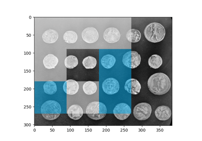

[Multi-Block Local Binary Pattern for texture classification](https://scikit-image.org/docs/0.25.x/auto_examples/features_detection/plot_multiblock_local_binary_pattern.html#sphx-glr-auto-examples-features-detection-plot-multiblock-local-binary-pattern-py)

Multi-Block Local Binary Pattern for texture classification

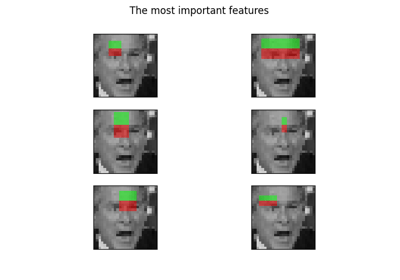

[Face classification using Haar-like feature descriptor](https://scikit-image.org/docs/0.25.x/auto_examples/applications/plot_haar_extraction_selection_classification.html#sphx-glr-auto-examples-applications-plot-haar-extraction-selection-classification-py)

Face classification using Haar-like feature descriptor

**`skimage.transform.integrate(ii, start, end)` [[source]](https://github.com/scikit-image/scikit-image/blob/v0.25.0/skimage/transform/integral.py#L48-L145)**

Use an integral image to integrate over a given window.

**Parameters:**

**`iindarray`**

Integral image.

**`startList of tuples, each tuple of length equal to dimension of ii`**

Coordinates of top left corner of window(s). Each tuple in the list contains the starting row, col, … index i.e `[(row_win1, col_win1, ...), (row_win2, col_win2,...), ...]`.

**`endList of tuples, each tuple of length equal to dimension of ii`**

Coordinates of bottom right corner of window(s). Each tuple in the list containing the end row, col, … index i.e `[(row_win1, col_win1, ...), (row_win2, col_win2, ...), ...]`.

**Returns:**

**`Sscalar or ndarray`**

Integral (sum) over the given window(s).

See also

**`integral_image`**

Create an integral image / summed area table.

#### Examples

```
>>> arr = np.ones((5, 6), dtype=float)
>>> ii = integral_image(arr)
>>> integrate(ii, (1, 0), (1, 2))  # sum from (1, 0) to (1, 2)
array([3.])
>>> integrate(ii, [(3, 3)], [(4, 5)])  # sum from (3, 3) to (4, 5)
array([6.])
>>> # sum from (1, 0) to (1, 2) and from (3, 3) to (4, 5)
>>> integrate(ii, [(1, 0), (3, 3)], [(1, 2), (4, 5)])
array([3., 6.])
```

**`skimage.transform.iradon(radon_image, theta=None, output_size=None, filter_name='ramp', interpolation='linear', circle=True, preserve_range=True)` [[source]](https://github.com/scikit-image/scikit-image/blob/v0.25.0/skimage/transform/radon_transform.py#L187-L323)**

Inverse radon transform.

Reconstruct an image from the radon transform, using the filtered back projection algorithm.

**Parameters:**

**`radon_imagendarray`**

Image containing radon transform (sinogram). Each column of the image corresponds to a projection along a different angle. The tomography rotation axis should lie at the pixel index `radon_image.shape[0] // 2` along the 0th dimension of `radon_image`.

**`thetaarray, optional`**

Reconstruction angles (in degrees). Default: m angles evenly spaced between 0 and 180 (if the shape of `radon_image` is (N, M)).

**`output_sizeint, optional`**

Number of rows and columns in the reconstruction.

**`filter_namestr, optional`**

Filter used in frequency domain filtering. Ramp filter used by default. Filters available: ramp, shepp-logan, cosine, hamming, hann. Assign None to use no filter.

**`interpolationstr, optional`**

Interpolation method used in reconstruction. Methods available: ‘linear’, ‘nearest’, and ‘cubic’ (‘cubic’ is slow).

**`circleboolean, optional`**

Assume the reconstructed image is zero outside the inscribed circle. Also changes the default output_size to match the behaviour of `radon` called with `circle=True`.

**`preserve_rangebool, optional`**

Whether to keep the original range of values. Otherwise, the input image is converted according to the conventions of `img_as_float`. Also see https://scikit-image.org/docs/dev/user_guide/data_types.html

**Returns:**

**`reconstructedndarray`**

Reconstructed image. The rotation axis will be located in the pixel with indices `(reconstructed.shape[0] // 2, reconstructed.shape[1] // 2)`.

Changed in version 0.19: In `iradon`, `filter` argument is deprecated in favor of `filter_name`.

#### Notes

It applies the Fourier slice theorem to reconstruct an image by multiplying the frequency domain of the filter with the FFT of the projection data. This algorithm is called filtered back projection.

#### References

[1]

AC Kak, M Slaney, “Principles of Computerized Tomographic Imaging”, IEEE Press 1988.

[2]

B.R. Ramesh, N. Srinivasa, K. Rajgopal, “An Algorithm for Computing the Discrete Radon Transform With Some Applications”, Proceedings of the Fourth IEEE Region 10 International Conference, TENCON ‘89, 1989

[Radon transform](https://scikit-image.org/docs/0.25.x/auto_examples/transform/plot_radon_transform.html#sphx-glr-auto-examples-transform-plot-radon-transform-py)

Radon transform

**`skimage.transform.iradon_sart(radon_image, theta=None, image=None, projection_shifts=None, clip=None, relaxation=0.15, dtype=None)` [[source]](https://github.com/scikit-image/scikit-image/blob/v0.25.0/skimage/transform/radon_transform.py#L385-L536)**

Inverse radon transform.

Reconstruct an image from the radon transform, using a single iteration of the Simultaneous Algebraic Reconstruction Technique (SART) algorithm.

**Parameters:**

**`radon_imagendarray, shape (M, N)`**

Image containing radon transform (sinogram). Each column of the image corresponds to a projection along a different angle. The tomography rotation axis should lie at the pixel index `radon_image.shape[0] // 2` along the 0th dimension of `radon_image`.

**`thetaarray, shape (N,), optional`**

Reconstruction angles (in degrees). Default: m angles evenly spaced between 0 and 180 (if the shape of `radon_image` is (N, M)).

**`imagendarray, shape (M, M), optional`**

Image containing an initial reconstruction estimate. Default is an array of zeros.

**`projection_shiftsarray, shape (N,), optional`**

Shift the projections contained in `radon_image` (the sinogram) by this many pixels before reconstructing the image. The i’th value defines the shift of the i’th column of `radon_image`.

**`cliplength-2 sequence of floats, optional`**

Force all values in the reconstructed tomogram to lie in the range `[clip[0], clip[1]]`

**`relaxationfloat, optional`**

Relaxation parameter for the update step. A higher value can improve the convergence rate, but one runs the risk of instabilities. Values close to or higher than 1 are not recommended.

**`dtypedtype, optional`**

Output data type, must be floating point. By default, if input data type is not float, input is cast to double, otherwise dtype is set to input data type.

**Returns:**

**`reconstructedndarray`**

Reconstructed image. The rotation axis will be located in the pixel with indices `(reconstructed.shape[0] // 2, reconstructed.shape[1] // 2)`.

#### Notes

Algebraic Reconstruction Techniques are based on formulating the tomography reconstruction problem as a set of linear equations. Along each ray, the projected value is the sum of all the values of the cross section along the ray. A typical feature of SART (and a few other variants of algebraic techniques) is that it samples the cross section at equidistant points along the ray, using linear interpolation between the pixel values of the cross section. The resulting set of linear equations are then solved using a slightly modified Kaczmarz method.

When using SART, a single iteration is usually sufficient to obtain a good reconstruction. Further iterations will tend to enhance high-frequency information, but will also often increase the noise.

#### References

[1]

AC Kak, M Slaney, “Principles of Computerized Tomographic Imaging”, IEEE Press 1988.

[2]

AH Andersen, AC Kak, “Simultaneous algebraic reconstruction technique (SART): a superior implementation of the ART algorithm”, Ultrasonic Imaging 6 pp 81–94 (1984)

[3]

S Kaczmarz, “Angenäherte auflösung von systemen linearer gleichungen”, Bulletin International de l’Academie Polonaise des Sciences et des Lettres 35 pp 355–357 (1937)

[4]

Kohler, T. “A projection access scheme for iterative reconstruction based on the golden section.” Nuclear Science Symposium Conference Record, 2004 IEEE. Vol. 6. IEEE, 2004.

[5]

Kaczmarz’ method, Wikipedia, https://en.wikipedia.org/wiki/Kaczmarz_method

[Radon transform](https://scikit-image.org/docs/0.25.x/auto_examples/transform/plot_radon_transform.html#sphx-glr-auto-examples-transform-plot-radon-transform-py)

Radon transform

**`skimage.transform.matrix_transform(coords, matrix)` [[source]](https://github.com/scikit-image/scikit-image/blob/v0.25.0/skimage/transform/_geometric.py#L1756-L1772)**

Apply 2D matrix transform.

**Parameters:**

**`coords(N, 2) array_like`**

x, y coordinates to transform

**`matrix(3, 3) array_like`**

Homogeneous transformation matrix.

**Returns:**

**`coords(N, 2) array`**

Transformed coordinates.

**`skimage.transform.order_angles_golden_ratio(theta)` [[source]](https://github.com/scikit-image/scikit-image/blob/v0.25.0/skimage/transform/radon_transform.py#L326-L382)**

Order angles to reduce the amount of correlated information in subsequent projections.

**Parameters:**

**`thetaarray of floats, shape (M,)`**

Projection angles in degrees. Duplicate angles are not allowed.

**Returns:**

**`indices_generatorgenerator yielding unsigned integers`**

The returned generator yields indices into `theta` such that `theta[indices]` gives the approximate golden ratio ordering of the projections. In total, `len(theta)` indices are yielded. All non-negative integers < `len(theta)` are yielded exactly once.

#### Notes

The method used here is that of the golden ratio introduced by T. Kohler.

#### References

[1]

Kohler, T. “A projection access scheme for iterative reconstruction based on the golden section.” Nuclear Science Symposium Conference Record, 2004 IEEE. Vol. 6. IEEE, 2004.

[2]

Winkelmann, Stefanie, et al. “An optimal radial profile order based on the Golden Ratio for time-resolved MRI.” Medical Imaging, IEEE Transactions on 26.1 (2007): 68-76.

**`skimage.transform.probabilistic_hough_line(image, threshold=10, line_length=50, line_gap=10, theta=None, rng=None)` [[source]](https://github.com/scikit-image/scikit-image/blob/v0.25.0/skimage/transform/hough_transform.py#L250-L302)**

Return lines from a progressive probabilistic line Hough transform.

**Parameters:**

**`imagendarray, shape (M, N)`**

Input image with nonzero values representing edges.

**`thresholdint, optional`**

Threshold

**`line_lengthint, optional`**

Minimum accepted length of detected lines. Increase the parameter to extract longer lines.

**`line_gapint, optional`**

Maximum gap between pixels to still form a line. Increase the parameter to merge broken lines more aggressively.

**`thetandarray of dtype, shape (K,), optional`**

Angles at which to compute the transform, in radians. Defaults to a vector of 180 angles evenly spaced in the range [-pi/2, pi/2).

**`rng{numpy.random.Generator, int}, optional`**

Pseudo-random number generator. By default, a PCG64 generator is used (see [`numpy.random.default_rng()`](https://numpy.org/doc/stable/reference/random/generator.html#numpy.random.default_rng)). If `rng` is an int, it is used to seed the generator.

**Returns:**

**`lineslist`**

List of lines identified, lines in format ((x0, y0), (x1, y1)), indicating line start and end.

#### References

[1]

C. Galamhos, J. Matas and J. Kittler, “Progressive probabilistic Hough transform for line detection”, in IEEE Computer Society Conference on Computer Vision and Pattern Recognition, 1999.

[Straight line Hough transform](https://scikit-image.org/docs/0.25.x/auto_examples/edges/plot_line_hough_transform.html#sphx-glr-auto-examples-edges-plot-line-hough-transform-py)

Straight line Hough transform

**`skimage.transform.pyramid_expand(image, upscale=2, sigma=None, order=1, mode='reflect', cval=0, preserve_range=False, *, channel_axis=None)` [[source]](https://github.com/scikit-image/scikit-image/blob/v0.25.0/skimage/transform/pyramids.py#L114-L187)**

Upsample and then smooth image.

**Parameters:**

**`imagendarray`**

Input image.

**`upscalefloat, optional`**

Upscale factor.

**`sigmafloat, optional`**

Sigma for Gaussian filter. Default is `2 * upscale / 6.0` which corresponds to a filter mask twice the size of the scale factor that covers more than 99% of the Gaussian distribution.

**`orderint, optional`**

Order of splines used in interpolation of upsampling. See `skimage.transform.warp` for detail.

**`mode{‘reflect’, ‘constant’, ‘edge’, ‘symmetric’, ‘wrap’}, optional`**

The mode parameter determines how the array borders are handled, where cval is the value when mode is equal to ‘constant’.

**`cvalfloat, optional`**

Value to fill past edges of input if mode is ‘constant’.

**`preserve_rangebool, optional`**

Whether to keep the original range of values. Otherwise, the input image is converted according to the conventions of `img_as_float`. Also see https://scikit-image.org/docs/dev/user_guide/data_types.html

**`channel_axisint or None, optional`**

If None, the image is assumed to be a grayscale (single channel) image. Otherwise, this parameter indicates which axis of the array corresponds to channels.

Added in version 0.19: `channel_axis` was added in 0.19.

**Returns:**

**`outarray`**

Upsampled and smoothed float image.

#### References

[1]

http://persci.mit.edu/pub_pdfs/pyramid83.pdf

**`skimage.transform.pyramid_gaussian(image, max_layer=-1, downscale=2, sigma=None, order=1, mode='reflect', cval=0, preserve_range=False, *, channel_axis=None)` [[source]](https://github.com/scikit-image/scikit-image/blob/v0.25.0/skimage/transform/pyramids.py#L190-L289)**

Yield images of the Gaussian pyramid formed by the input image.

Recursively applies the `pyramid_reduce` function to the image, and yields the downscaled images.

Note that the first image of the pyramid will be the original, unscaled image. The total number of images is `max_layer + 1`. In case all layers are computed, the last image is either a one-pixel image or the image where the reduction does not change its shape.

**Parameters:**

**`imagendarray`**

Input image.

**`max_layerint, optional`**

Number of layers for the pyramid. 0th layer is the original image. Default is -1 which builds all possible layers.

**`downscalefloat, optional`**

Downscale factor.

**`sigmafloat, optional`**

Sigma for Gaussian filter. Default is `2 * downscale / 6.0` which corresponds to a filter mask twice the size of the scale factor that covers more than 99% of the Gaussian distribution.

**`orderint, optional`**

Order of splines used in interpolation of downsampling. See `skimage.transform.warp` for detail.

**`mode{‘reflect’, ‘constant’, ‘edge’, ‘symmetric’, ‘wrap’}, optional`**

The mode parameter determines how the array borders are handled, where cval is the value when mode is equal to ‘constant’.

**`cvalfloat, optional`**

Value to fill past edges of input if mode is ‘constant’.

**`preserve_rangebool, optional`**

Whether to keep the original range of values. Otherwise, the input image is converted according to the conventions of `img_as_float`. Also see https://scikit-image.org/docs/dev/user_guide/data_types.html

**`channel_axisint or None, optional`**

If None, the image is assumed to be a grayscale (single channel) image. Otherwise, this parameter indicates which axis of the array corresponds to channels.

Added in version 0.19: `channel_axis` was added in 0.19.

**Returns:**

**`pyramidgenerator`**

Generator yielding pyramid layers as float images.

#### References

[1]

http://persci.mit.edu/pub_pdfs/pyramid83.pdf

[figure not shown]

[Build image pyramids](https://scikit-image.org/docs/0.25.x/auto_examples/transform/plot_pyramid.html#sphx-glr-auto-examples-transform-plot-pyramid-py)

Build image pyramids

**`skimage.transform.pyramid_laplacian(image, max_layer=-1, downscale=2, sigma=None, order=1, mode='reflect', cval=0, preserve_range=False, *, channel_axis=None)` [[source]](https://github.com/scikit-image/scikit-image/blob/v0.25.0/skimage/transform/pyramids.py#L292-L408)**

Yield images of the laplacian pyramid formed by the input image.

Each layer contains the difference between the downsampled and the downsampled, smoothed image:

```
layer = resize(prev_layer) - smooth(resize(prev_layer))
```

Note that the first image of the pyramid will be the difference between the original, unscaled image and its smoothed version. The total number of images is `max_layer + 1`. In case all layers are computed, the last image is either a one-pixel image or the image where the reduction does not change its shape.

**Parameters:**

**`imagendarray`**

Input image.

**`max_layerint, optional`**

Number of layers for the pyramid. 0th layer is the original image. Default is -1 which builds all possible layers.

**`downscalefloat, optional`**

Downscale factor.

**`sigmafloat, optional`**

Sigma for Gaussian filter. Default is `2 * downscale / 6.0` which corresponds to a filter mask twice the size of the scale factor that covers more than 99% of the Gaussian distribution.

**`orderint, optional`**

Order of splines used in interpolation of downsampling. See `skimage.transform.warp` for detail.

**`mode{‘reflect’, ‘constant’, ‘edge’, ‘symmetric’, ‘wrap’}, optional`**

The mode parameter determines how the array borders are handled, where cval is the value when mode is equal to ‘constant’.

**`cvalfloat, optional`**

Value to fill past edges of input if mode is ‘constant’.

**`preserve_rangebool, optional`**

Whether to keep the original range of values. Otherwise, the input image is converted according to the conventions of `img_as_float`. Also see https://scikit-image.org/docs/dev/user_guide/data_types.html

**`channel_axisint or None, optional`**

If None, the image is assumed to be a grayscale (single channel) image. Otherwise, this parameter indicates which axis of the array corresponds to channels.

Added in version 0.19: `channel_axis` was added in 0.19.

**Returns:**

**`pyramidgenerator`**

Generator yielding pyramid layers as float images.

#### References

[1]

http://persci.mit.edu/pub_pdfs/pyramid83.pdf

[2]

http://sepwww.stanford.edu/data/media/public/sep/morgan/texturematch/paper_html/node3.html

**`skimage.transform.pyramid_reduce(image, downscale=2, sigma=None, order=1, mode='reflect', cval=0, preserve_range=False, *, channel_axis=None)` [[source]](https://github.com/scikit-image/scikit-image/blob/v0.25.0/skimage/transform/pyramids.py#L37-L111)**

Smooth and then downsample image.

**Parameters:**

**`imagendarray`**

Input image.

**`downscalefloat, optional`**

Downscale factor.

**`sigmafloat, optional`**

Sigma for Gaussian filter. Default is `2 * downscale / 6.0` which corresponds to a filter mask twice the size of the scale factor that covers more than 99% of the Gaussian distribution.

**`orderint, optional`**

Order of splines used in interpolation of downsampling. See `skimage.transform.warp` for detail.

**`mode{‘reflect’, ‘constant’, ‘edge’, ‘symmetric’, ‘wrap’}, optional`**

The mode parameter determines how the array borders are handled, where cval is the value when mode is equal to ‘constant’.

**`cvalfloat, optional`**

Value to fill past edges of input if mode is ‘constant’.

**`preserve_rangebool, optional`**

Whether to keep the original range of values. Otherwise, the input image is converted according to the conventions of `img_as_float`. Also see https://scikit-image.org/docs/dev/user_guide/data_types.html

**`channel_axisint or None, optional`**

If None, the image is assumed to be a grayscale (single channel) image. Otherwise, this parameter indicates which axis of the array corresponds to channels.

Added in version 0.19: `channel_axis` was added in 0.19.

**Returns:**

**`outarray`**

Smoothed and downsampled float image.

#### References

[1]

http://persci.mit.edu/pub_pdfs/pyramid83.pdf

**`skimage.transform.radon(image, theta=None, circle=True, *, preserve_range=False)` [[source]](https://github.com/scikit-image/scikit-image/blob/v0.25.0/skimage/transform/radon_transform.py#L16-L114)**

Calculates the radon transform of an image given specified projection angles.

**Parameters:**

**`imagendarray`**

Input image. The rotation axis will be located in the pixel with indices `(image.shape[0] // 2, image.shape[1] // 2)`.

**`thetaarray, optional`**

Projection angles (in degrees). If [`None`](https://docs.python.org/3/library/constants.html#None), the value is set to np.arange(180).

**`circleboolean, optional`**

Assume image is zero outside the inscribed circle, making the width of each projection (the first dimension of the sinogram) equal to `min(image.shape)`.

**`preserve_rangebool, optional`**

Whether to keep the original range of values. Otherwise, the input image is converted according to the conventions of `img_as_float`. Also see https://scikit-image.org/docs/dev/user_guide/data_types.html

**Returns:**

**`radon_imagendarray`**

Radon transform (sinogram). The tomography rotation axis will lie at the pixel index `radon_image.shape[0] // 2` along the 0th dimension of `radon_image`.

#### Notes

Based on code of Justin K. Romberg (https://www.clear.rice.edu/elec431/projects96/DSP/bpanalysis.html)

#### References

[1]

AC Kak, M Slaney, “Principles of Computerized Tomographic Imaging”, IEEE Press 1988.

[2]

B.R. Ramesh, N. Srinivasa, K. Rajgopal, “An Algorithm for Computing the Discrete Radon Transform With Some Applications”, Proceedings of the Fourth IEEE Region 10 International Conference, TENCON ‘89, 1989

[Radon transform](https://scikit-image.org/docs/0.25.x/auto_examples/transform/plot_radon_transform.html#sphx-glr-auto-examples-transform-plot-radon-transform-py)

Radon transform

**`skimage.transform.rescale(image, scale, order=None, mode='reflect', cval=0, clip=True, preserve_range=False, anti_aliasing=None, anti_aliasing_sigma=None, *, channel_axis=None)` [[source]](https://github.com/scikit-image/scikit-image/blob/v0.25.0/skimage/transform/_warps.py#L212-L327)**

Scale image by a certain factor.

Performs interpolation to up-scale or down-scale N-dimensional images. Note that anti-aliasing should be enabled when down-sizing images to avoid aliasing artifacts. For down-sampling with an integer factor also see `skimage.transform.downscale_local_mean`.

**Parameters:**

**`image(M, N[, …][, C]) ndarray`**

Input image.

**`scale{float, tuple of floats}`**

Scale factors for spatial dimensions. Separate scale factors can be defined as (m, n[, …]).

**Returns:**

**`scaledndarray`**

Scaled version of the input.

**Other Parameters:**

**`orderint, optional`**

The order of the spline interpolation, default is 0 if image.dtype is bool and 1 otherwise. The order has to be in the range 0-5. See `skimage.transform.warp` for detail.

**`mode{‘constant’, ‘edge’, ‘symmetric’, ‘reflect’, ‘wrap’}, optional`**

Points outside the boundaries of the input are filled according to the given mode. Modes match the behaviour of [`numpy.pad`](https://numpy.org/doc/stable/reference/generated/numpy.pad.html#numpy.pad).

**`cvalfloat, optional`**

Used in conjunction with mode ‘constant’, the value outside the image boundaries.

**`clipbool, optional`**

Whether to clip the output to the range of values of the input image. This is enabled by default, since higher order interpolation may produce values outside the given input range.

**`preserve_rangebool, optional`**

Whether to keep the original range of values. Otherwise, the input image is converted according to the conventions of `img_as_float`. Also see https://scikit-image.org/docs/dev/user_guide/data_types.html

**`anti_aliasingbool, optional`**

Whether to apply a Gaussian filter to smooth the image prior to down-scaling. It is crucial to filter when down-sampling the image to avoid aliasing artifacts. If input image data type is bool, no anti-aliasing is applied.

**`anti_aliasing_sigma{float, tuple of floats}, optional`**

Standard deviation for Gaussian filtering to avoid aliasing artifacts. By default, this value is chosen as (s - 1) / 2 where s is the down-scaling factor.

**`channel_axisint or None, optional`**

If None, the image is assumed to be a grayscale (single channel) image. Otherwise, this parameter indicates which axis of the array corresponds to channels.

Added in version 0.19: `channel_axis` was added in 0.19.

#### Notes

Modes ‘reflect’ and ‘symmetric’ are similar, but differ in whether the edge pixels are duplicated during the reflection. As an example, if an array has values [0, 1, 2] and was padded to the right by four values using symmetric, the result would be [0, 1, 2, 2, 1, 0, 0], while for reflect it would be [0, 1, 2, 1, 0, 1, 2].

#### Examples

```
>>> from skimage import data
>>> from skimage.transform import rescale
>>> image = data.camera()
>>> rescale(image, 0.1).shape
(51, 51)
>>> rescale(image, 0.5).shape
(256, 256)
```

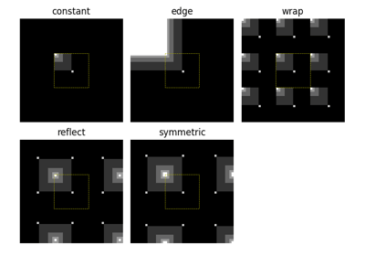

[Interpolation: Edge Modes](https://scikit-image.org/docs/0.25.x/auto_examples/transform/plot_edge_modes.html#sphx-glr-auto-examples-transform-plot-edge-modes-py)

Interpolation: Edge Modes

[Rescale, resize, and downscale](https://scikit-image.org/docs/0.25.x/auto_examples/transform/plot_rescale.html#sphx-glr-auto-examples-transform-plot-rescale-py)

Rescale, resize, and downscale

[Radon transform](https://scikit-image.org/docs/0.25.x/auto_examples/transform/plot_radon_transform.html#sphx-glr-auto-examples-transform-plot-radon-transform-py)

Radon transform

[Using Polar and Log-Polar Transformations for Registration](https://scikit-image.org/docs/0.25.x/auto_examples/registration/plot_register_rotation.html#sphx-glr-auto-examples-registration-plot-register-rotation-py)

Using Polar and Log-Polar Transformations for Registration

**`skimage.transform.resize(image, output_shape, order=None, mode='reflect', cval=0, clip=True, preserve_range=False, anti_aliasing=None, anti_aliasing_sigma=None)` [[source]](https://github.com/scikit-image/scikit-image/blob/v0.25.0/skimage/transform/_warps.py#L71-L209)**

Resize image to match a certain size.

Performs interpolation to up-size or down-size N-dimensional images. Note that anti-aliasing should be enabled when down-sizing images to avoid aliasing artifacts. For downsampling with an integer factor also see `skimage.transform.downscale_local_mean`.

**Parameters:**

**`imagendarray`**

Input image.

**`output_shapeiterable`**

Size of the generated output image `(rows, cols[, ...][, dim])`. If `dim` is not provided, the number of channels is preserved. In case the number of input channels does not equal the number of output channels a n-dimensional interpolation is applied.

**Returns:**

**`resizedndarray`**

Resized version of the input.

**Other Parameters:**

**`orderint, optional`**

The order of the spline interpolation, default is 0 if image.dtype is bool and 1 otherwise. The order has to be in the range 0-5. See `skimage.transform.warp` for detail.

**`mode{‘constant’, ‘edge’, ‘symmetric’, ‘reflect’, ‘wrap’}, optional`**

Points outside the boundaries of the input are filled according to the given mode. Modes match the behaviour of [`numpy.pad`](https://numpy.org/doc/stable/reference/generated/numpy.pad.html#numpy.pad).

**`cvalfloat, optional`**

Used in conjunction with mode ‘constant’, the value outside the image boundaries.

**`clipbool, optional`**

Whether to clip the output to the range of values of the input image. This is enabled by default, since higher order interpolation may produce values outside the given input range.

**`preserve_rangebool, optional`**

Whether to keep the original range of values. Otherwise, the input image is converted according to the conventions of `img_as_float`. Also see https://scikit-image.org/docs/dev/user_guide/data_types.html

**`anti_aliasingbool, optional`**

Whether to apply a Gaussian filter to smooth the image prior to downsampling. It is crucial to filter when downsampling the image to avoid aliasing artifacts. If not specified, it is set to True when downsampling an image whose data type is not bool. It is also set to False when using nearest neighbor interpolation (`order` == 0) with integer input data type.

**`anti_aliasing_sigma{float, tuple of floats}, optional`**

Standard deviation for Gaussian filtering used when anti-aliasing. By default, this value is chosen as (s - 1) / 2 where s is the downsampling factor, where s > 1. For the up-size case, s < 1, no anti-aliasing is performed prior to rescaling.

#### Notes

Modes ‘reflect’ and ‘symmetric’ are similar, but differ in whether the edge pixels are duplicated during the reflection. As an example, if an array has values [0, 1, 2] and was padded to the right by four values using symmetric, the result would be [0, 1, 2, 2, 1, 0, 0], while for reflect it would be [0, 1, 2, 1, 0, 1, 2].

#### Examples

```
>>> from skimage import data
>>> from skimage.transform import resize
>>> image = data.camera()
>>> resize(image, (100, 100)).shape
(100, 100)
```

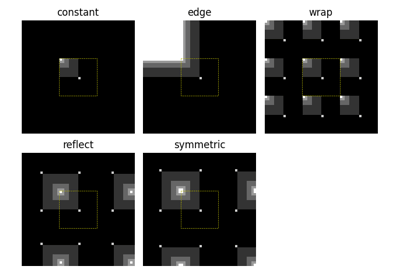

[Interpolation: Edge Modes](https://scikit-image.org/docs/0.25.x/auto_examples/transform/plot_edge_modes.html#sphx-glr-auto-examples-transform-plot-edge-modes-py)

Interpolation: Edge Modes

[Rescale, resize, and downscale](https://scikit-image.org/docs/0.25.x/auto_examples/transform/plot_rescale.html#sphx-glr-auto-examples-transform-plot-rescale-py)

Rescale, resize, and downscale

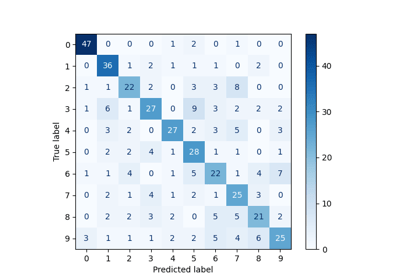

[Fisher vector feature encoding](https://scikit-image.org/docs/0.25.x/auto_examples/features_detection/plot_fisher_vector.html#sphx-glr-auto-examples-features-detection-plot-fisher-vector-py)

Fisher vector feature encoding

**`skimage.transform.resize_local_mean(image, output_shape, grid_mode=True, preserve_range=False, *, channel_axis=None)` [[source]](https://github.com/scikit-image/scikit-image/blob/v0.25.0/skimage/transform/_warps.py#L1274-L1388)**

Resize an array with the local mean / bilinear scaling.

**Parameters:**

**`imagendarray`**

Input image. If this is a multichannel image, the axis corresponding to channels should be specified using `channel_axis`.

**`output_shapeiterable`**

Size of the generated output image. When `channel_axis` is not None, the `channel_axis` should either be omitted from `output_shape` or the `output_shape[channel_axis]` must match `image.shape[channel_axis]`. If the length of `output_shape` exceeds image.ndim, additional singleton dimensions will be appended to the input `image` as needed.

**`grid_modebool, optional`**

Defines `image` pixels position: if True, pixels are assumed to be at grid intersections, otherwise at cell centers. As a consequence, for example, a 1d signal of length 5 is considered to have length 4 when `grid_mode` is False, but length 5 when `grid_mode` is True. See the following visual illustration:

```
| pixel 1 | pixel 2 | pixel 3 | pixel 4 | pixel 5 |
     |<-------------------------------------->|
                        vs.
|<----------------------------------------------->|
```

The starting point of the arrow in the diagram above corresponds to coordinate location 0 in each mode.

**`preserve_rangebool, optional`**

Whether to keep the original range of values. Otherwise, the input image is converted according to the conventions of `img_as_float`. Also see https://scikit-image.org/docs/dev/user_guide/data_types.html

**Returns:**

**`resizedndarray`**

Resized version of the input.

See also

**`resize,` `downscale_local_mean`**

#### Notes

This method is sometimes referred to as “area-based” interpolation or “pixel mixing” interpolation [1]. When `grid_mode` is True, it is equivalent to using OpenCV’s resize with `INTER_AREA` interpolation mode. It is commonly used for image downsizing. If the downsizing factors are integers, then `downscale_local_mean` should be preferred instead.

#### References

[]

http://entropymine.com/imageworsener/pixelmixing/

#### Examples

```
>>> from skimage import data
>>> from skimage.transform import resize_local_mean
>>> image = data.camera()
>>> resize_local_mean(image, (100, 100)).shape
(100, 100)
```

**`skimage.transform.rotate(image, angle, resize=False, center=None, order=None, mode='constant', cval=0, clip=True, preserve_range=False)` [[source]](https://github.com/scikit-image/scikit-image/blob/v0.25.0/skimage/transform/_warps.py#L330-L453)**

Rotate image by a certain angle around its center.

**Parameters:**

**`imagendarray`**

Input image.

**`anglefloat`**

Rotation angle in degrees in counter-clockwise direction.

**`resizebool, optional`**

Determine whether the shape of the output image will be automatically calculated, so the complete rotated image exactly fits. Default is False.

**`centeriterable of length 2`**

The rotation center. If `center=None`, the image is rotated around its center, i.e. `center=(cols / 2 - 0.5, rows / 2 - 0.5)`. Please note that this parameter is (cols, rows), contrary to normal skimage ordering.

**Returns:**

**`rotatedndarray`**

Rotated version of the input.

**Other Parameters:**

**`orderint, optional`**

The order of the spline interpolation, default is 0 if image.dtype is bool and 1 otherwise. The order has to be in the range 0-5. See `skimage.transform.warp` for detail.

**`mode{‘constant’, ‘edge’, ‘symmetric’, ‘reflect’, ‘wrap’}, optional`**

Points outside the boundaries of the input are filled according to the given mode. Modes match the behaviour of [`numpy.pad`](https://numpy.org/doc/stable/reference/generated/numpy.pad.html#numpy.pad).

**`cvalfloat, optional`**

Used in conjunction with mode ‘constant’, the value outside the image boundaries.

**`clipbool, optional`**

Whether to clip the output to the range of values of the input image. This is enabled by default, since higher order interpolation may produce values outside the given input range.

**`preserve_rangebool, optional`**

Whether to keep the original range of values. Otherwise, the input image is converted according to the conventions of `img_as_float`. Also see https://scikit-image.org/docs/dev/user_guide/data_types.html

#### Notes

Modes ‘reflect’ and ‘symmetric’ are similar, but differ in whether the edge pixels are duplicated during the reflection. As an example, if an array has values [0, 1, 2] and was padded to the right by four values using symmetric, the result would be [0, 1, 2, 2, 1, 0, 0], while for reflect it would be [0, 1, 2, 1, 0, 1, 2].

#### Examples

```
>>> from skimage import data
>>> from skimage.transform import rotate
>>> image = data.camera()
>>> rotate(image, 2).shape
(512, 512)
>>> rotate(image, 2, resize=True).shape
(530, 530)
>>> rotate(image, 90, resize=True).shape
(512, 512)
```

[Types of homographies](https://scikit-image.org/docs/0.25.x/auto_examples/transform/plot_transform_types.html#sphx-glr-auto-examples-transform-plot-transform-types-py)

Types of homographies

[Assemble images with simple image stitching](https://scikit-image.org/docs/0.25.x/auto_examples/registration/plot_stitching.html#sphx-glr-auto-examples-registration-plot-stitching-py)

Assemble images with simple image stitching

[Using Polar and Log-Polar Transformations for Registration](https://scikit-image.org/docs/0.25.x/auto_examples/registration/plot_register_rotation.html#sphx-glr-auto-examples-registration-plot-register-rotation-py)

Using Polar and Log-Polar Transformations for Registration

[ORB feature detector and binary descriptor](https://scikit-image.org/docs/0.25.x/auto_examples/features_detection/plot_orb.html#sphx-glr-auto-examples-features-detection-plot-orb-py)

ORB feature detector and binary descriptor

[BRIEF binary descriptor](https://scikit-image.org/docs/0.25.x/auto_examples/features_detection/plot_brief.html#sphx-glr-auto-examples-features-detection-plot-brief-py)

BRIEF binary descriptor

[figure not shown]

[SIFT feature detector and descriptor extractor](https://scikit-image.org/docs/0.25.x/auto_examples/features_detection/plot_sift.html#sphx-glr-auto-examples-features-detection-plot-sift-py)

SIFT feature detector and descriptor extractor

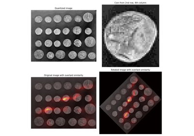

[Sliding window histogram](https://scikit-image.org/docs/0.25.x/auto_examples/features_detection/plot_windowed_histogram.html#sphx-glr-auto-examples-features-detection-plot-windowed-histogram-py)

Sliding window histogram

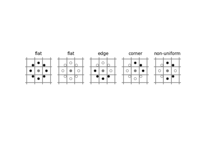

[Local Binary Pattern for texture classification](https://scikit-image.org/docs/0.25.x/auto_examples/features_detection/plot_local_binary_pattern.html#sphx-glr-auto-examples-features-detection-plot-local-binary-pattern-py)

Local Binary Pattern for texture classification

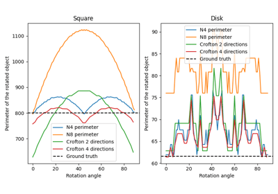

[Measure perimeters with different estimators](https://scikit-image.org/docs/0.25.x/auto_examples/segmentation/plot_perimeters.html#sphx-glr-auto-examples-segmentation-plot-perimeters-py)

Measure perimeters with different estimators

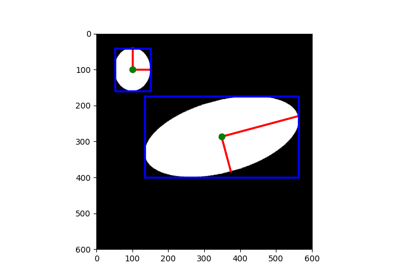

[Measure region properties](https://scikit-image.org/docs/0.25.x/auto_examples/segmentation/plot_regionprops.html#sphx-glr-auto-examples-segmentation-plot-regionprops-py)

Measure region properties

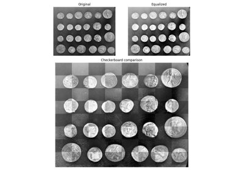

[Visual image comparison](https://scikit-image.org/docs/0.25.x/auto_examples/applications/plot_image_comparison.html#sphx-glr-auto-examples-applications-plot-image-comparison-py)

Visual image comparison

**`skimage.transform.swirl(image, center=None, strength=1, radius=100, rotation=0, output_shape=None, order=None, mode='reflect', cval=0, clip=True, preserve_range=False)` [[source]](https://github.com/scikit-image/scikit-image/blob/v0.25.0/skimage/transform/_warps.py#L520-L601)**

Perform a swirl transformation.

**Parameters:**

**`imagendarray`**

Input image.

**`center(column, row) tuple or (2,) ndarray, optional`**

Center coordinate of transformation.

**`strengthfloat, optional`**

The amount of swirling applied.

**`radiusfloat, optional`**

The extent of the swirl in pixels. The effect dies out rapidly beyond `radius`.

**`rotationfloat, optional`**

Additional rotation applied to the image.

**Returns:**

**`swirledndarray`**

Swirled version of the input.

**Other Parameters:**

**`output_shapetuple (rows, cols), optional`**

Shape of the output image generated. By default the shape of the input image is preserved.

**`orderint, optional`**

The order of the spline interpolation, default is 0 if image.dtype is bool and 1 otherwise. The order has to be in the range 0-5. See `skimage.transform.warp` for detail.

**`mode{‘constant’, ‘edge’, ‘symmetric’, ‘reflect’, ‘wrap’}, optional`**

Points outside the boundaries of the input are filled according to the given mode, with ‘reflect’ used as the default. Modes match the behaviour of [`numpy.pad`](https://numpy.org/doc/stable/reference/generated/numpy.pad.html#numpy.pad).

**`cvalfloat, optional`**

Used in conjunction with mode ‘constant’, the value outside the image boundaries.

**`clipbool, optional`**

Whether to clip the output to the range of values of the input image. This is enabled by default, since higher order interpolation may produce values outside the given input range.

**`preserve_rangebool, optional`**

Whether to keep the original range of values. Otherwise, the input image is converted according to the conventions of `img_as_float`. Also see https://scikit-image.org/docs/dev/user_guide/data_types.html

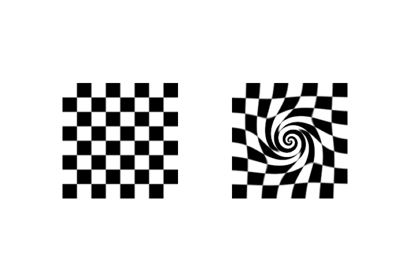

[Swirl](https://scikit-image.org/docs/0.25.x/auto_examples/transform/plot_swirl.html#sphx-glr-auto-examples-transform-plot-swirl-py)

Swirl

**`skimage.transform.warp(image, inverse_map, map_args=None, output_shape=None, order=None, mode='constant', cval=0.0, clip=True, preserve_range=False)` [[source]](https://github.com/scikit-image/scikit-image/blob/v0.25.0/skimage/transform/_warps.py#L764-L1042)**

Warp an image according to a given coordinate transformation.

**Parameters:**

**`imagendarray`**

Input image.

**`inverse_maptransformation object, callable cr = f(cr, **kwargs), or ndarray`**

Inverse coordinate map, which transforms coordinates in the output images into their corresponding coordinates in the input image.

There are a number of different options to define this map, depending on the dimensionality of the input image. A 2-D image can have 2 dimensions for gray-scale images, or 3 dimensions with color information.

- For 2-D images, you can directly pass a transformation object, e.g. `skimage.transform.SimilarityTransform`, or its inverse.
- For 2-D images, you can pass a `(3, 3)` homogeneous transformation matrix, e.g. `skimage.transform.SimilarityTransform.params`.
- For 2-D images, a function that transforms a `(M, 2)` array of `(col, row)` coordinates in the output image to their corresponding coordinates in the input image. Extra parameters to the function can be specified through `map_args`.
- For N-D images, you can directly pass an array of coordinates. The first dimension specifies the coordinates in the input image, while the subsequent dimensions determine the position in the output image. E.g. in case of 2-D images, you need to pass an array of shape `(2, rows, cols)`, where `rows` and `cols` determine the shape of the output image, and the first dimension contains the `(row, col)` coordinate in the input image. See [`scipy.ndimage.map_coordinates`](https://docs.scipy.org/doc/scipy/reference/generated/scipy.ndimage.map_coordinates.html#scipy.ndimage.map_coordinates) for further documentation.

Note, that a `(3, 3)` matrix is interpreted as a homogeneous transformation matrix, so you cannot interpolate values from a 3-D input, if the output is of shape `(3,)`.

See example section for usage.

**`map_argsdict, optional`**

Keyword arguments passed to `inverse_map`.

**`output_shapetuple (rows, cols), optional`**

Shape of the output image generated. By default the shape of the input image is preserved. Note that, even for multi-band images, only rows and columns need to be specified.

**`orderint, optional`**

**The order of interpolation. The order has to be in the range 0-5:**

- 0: Nearest-neighbor
- 1: Bi-linear (default)
- 2: Bi-quadratic
- 3: Bi-cubic
- 4: Bi-quartic
- 5: Bi-quintic

Default is 0 if image.dtype is bool and 1 otherwise.

**`mode{‘constant’, ‘edge’, ‘symmetric’, ‘reflect’, ‘wrap’}, optional`**

Points outside the boundaries of the input are filled according to the given mode. Modes match the behaviour of [`numpy.pad`](https://numpy.org/doc/stable/reference/generated/numpy.pad.html#numpy.pad).

**`cvalfloat, optional`**

Used in conjunction with mode ‘constant’, the value outside the image boundaries.

**`clipbool, optional`**

Whether to clip the output to the range of values of the input image. This is enabled by default, since higher order interpolation may produce values outside the given input range.

**`preserve_rangebool, optional`**

Whether to keep the original range of values. Otherwise, the input image is converted according to the conventions of `img_as_float`. Also see https://scikit-image.org/docs/dev/user_guide/data_types.html

**Returns:**

**`warpeddouble ndarray`**

The warped input image.